# Differential Expression Analysis (DEA)

### 4.2 Dotplots

`plotDeaDotPlot()` visualizes the results of DEA either by group…

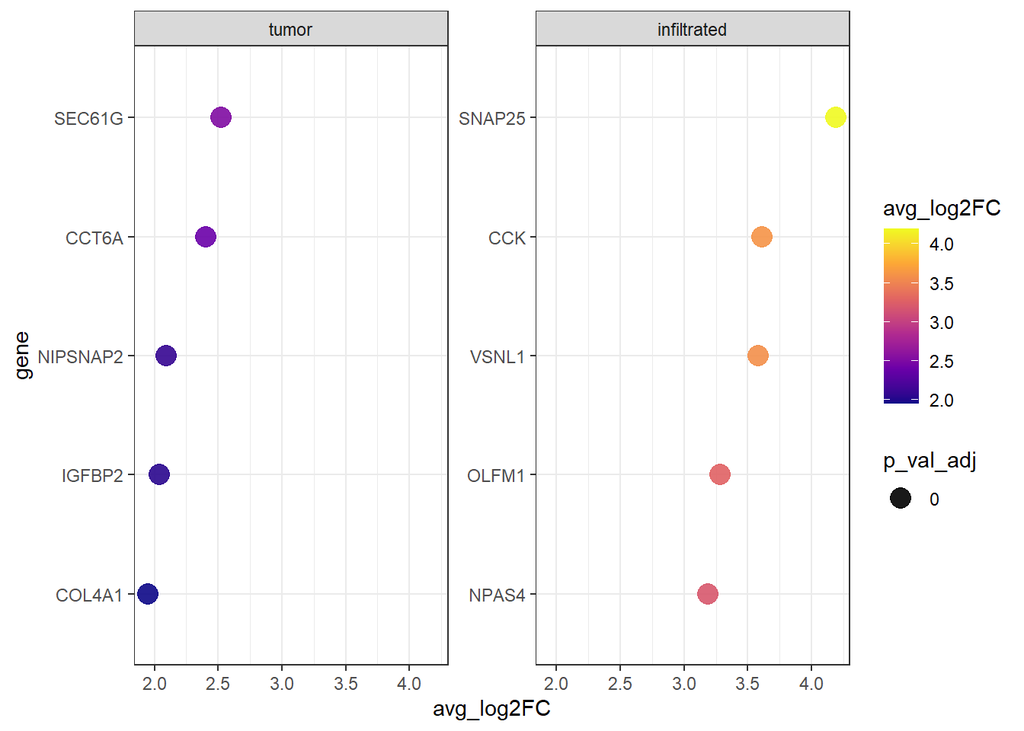

Fig.4 DEA-Dotplot by group.

```r
plotDeaDotPlot(
  object = object_t269,
  across = "histology",
  across_subset = c("tumor", "infiltrated"), # specify single groups if desired
  n_highest_lfc = 5,
  by_group = TRUE,
  scales = "free_y",
  nrow = 1
)
```

… or with all groups together.

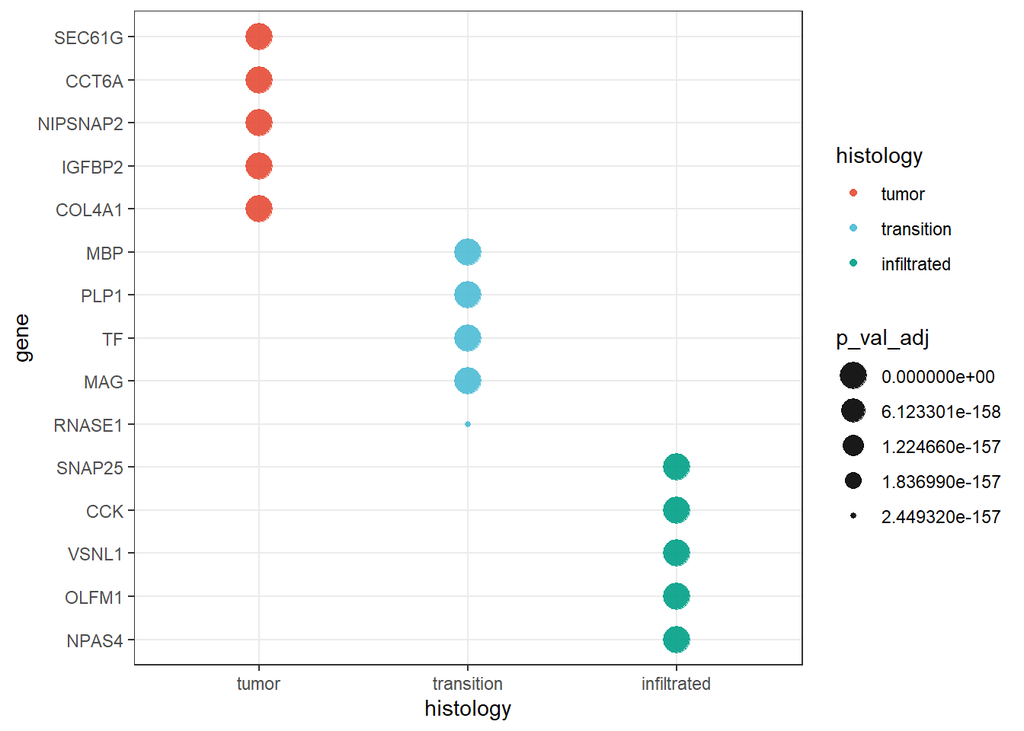

Fig.5 DEA-Dotplot for all groups.

```r
plotDeaDotPlot(
  object = object_t269,
  across = "histology",
  color_by = "histology",
  n_highest_lfc = 5,
  by_group = FALSE
)
```

### 4.3 Box- and Violinplots

There are additional ways to visualize the results of your DEA. As with almost all plotting functions in **SPATA2** a vector of gene names is necessary for the function to know which genes to plot. `getDeaGenes()` is the second function to extract DEA results and a wrapper around `getDeaResultsDf()` that returns a vector gene names.

```r
genes_of_interest <-
  getDeaGenes(
    object = object_t269,
    across = "histology", # the grouping variable
    method_de = "wilcox", # the method with which the results were computed
    n_highest_lfc = 10,
    max_adj_pval = 0.01
  )

head(genes_of_interest) # first six
```

```
##      tumor      tumor      tumor      tumor      tumor      tumor
##   "SEC61G"    "CCT6A" "NIPSNAP2"   "IGFBP2"   "COL4A1"      "PTN"
```

```r
tail(genes_of_interest) # last six
```

```
## infiltrated infiltrated infiltrated infiltrated infiltrated infiltrated
##     "NPAS4"      "RTN1"      "NRGN"      "SYT1"   "SLC17A7"     "NPTX2"
```

A vector of gene names as returned by `getDeaGenes()` is a perfectly valid input for other plotting functions.

```r
top_5_markers_269 <-
  getDeaGenes(
    object = object_t269,
    across = "histology",
    n_lowest_pval = 5,
    min_lfc = 0.1 # set min_lfc! else downregulated genes are included
    )

top_5_markers_269
```

```
##       tumor       tumor       tumor       tumor       tumor  transition  transition  transition  transition  transition infiltrated infiltrated infiltrated infiltrated infiltrated
##    "SEC61G"     "CCT6A"  "NIPSNAP2"    "IGFBP2"    "COL4A1"      "PLP1"       "MBP"        "TF"       "MAG"      "MOBP"    "SNAP25"       "CCK"     "VSNL1"     "OLFM1"     "NPAS4"
```

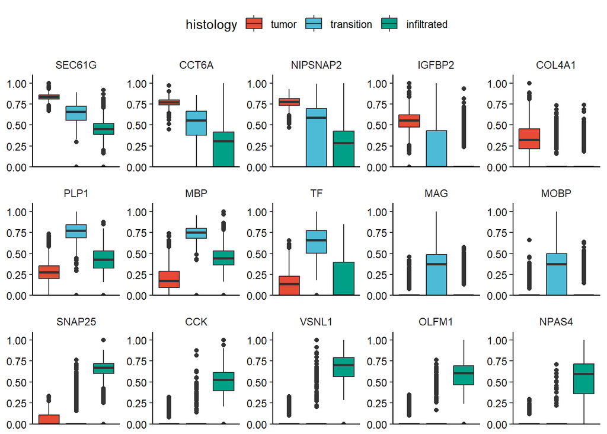

Fig.6 DEA-Boxplots

```r
# plot results for t269
plotBoxplot(
  object = object_t269,
  variables = top_5_markers_269,
  across = "histology",
  nrow = 3
  ) +
  theme(axis.text.x = element_blank(), axis.ticks.x = element_blank()) +
  legendTop()
```

### 4.3 Surface plots

`getDeaGenes()` complements `plotSurfaceComparison()`.

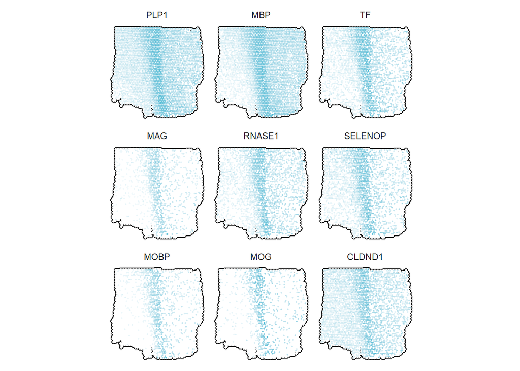

Fig.8 Surface plots with DEA results for sample 269_T.

```r
transition_markers <-
  getDeaGenes(object_t269, across = "histology", across_subset = "transition")

plotSurfaceComparison(
  object = object_t269,
  color_by = transition_markers[1:9],
  pt_clrsp = color_vector("npg")[2], # plot cluster color against white
  outline = TRUE,
  nrow = 3
  ) +
  legendNone()
```